# Lab 4

Brett White

```r
library(readxl)
defense <- read_excel('cyclonesFootball2019.xlsx', sheet='Defensive')
offense <- read_excel('cyclonesFootball2019.xlsx', sheet='Offensive')
biography <- read_excel('cyclonesFootball2019.xlsx', sheet='Biography')
library(tidyverse)
```

## Part one: Cleaning data

```r
defClean <- defense %>%
  mutate(
    Name = factor(Name),
    Opponent_Opponent = factor(Opponent_Opponent),
    across(c(-Name, -Opponent_Opponent), as.numeric)
  )
offClean <- offense %>%
  separate(`Passing_CMP-ATT`, c('CMP', 'ATT')) %>%
  mutate(
    Name = factor(Name),
    Opponent_Opponent = factor(Opponent_Opponent),
    across(c(-Name, -Opponent_Opponent), as.numeric),
    `Passing_CMP-ATT` = as.numeric(CMP) / as.numeric(ATT)
  ) %>%
  mutate(
    Receiving_REC = ifelse(is.na(Receiving_REC), 0, Receiving_REC),
    Receiving_YDS = ifelse(is.na(Receiving_YDS), 0, Receiving_YDS),
    Receiving_TD = ifelse(is.na(Receiving_TD), 0, Receiving_TD),
    Rushing_ATT = ifelse(is.na(Rushing_ATT), 0, Rushing_ATT),
    Rushing_YDS = ifelse(is.na(Rushing_YDS), 0, Rushing_YDS),
    Rushing_TD = ifelse(is.na(Rushing_TD), 0, Rushing_TD),
    Passing_YDS = ifelse(is.na(Passing_YDS), 0, Passing_YDS),
    Passing_TD = ifelse(is.na(Passing_TD), 0, Passing_TD),
    Passing_INT = ifelse(is.na(Passing_INT), 0, Passing_INT),
    `Passing_CMP-ATT` = ifelse(is.na(`Passing_CMP-ATT`), 0, `Passing_CMP-ATT`)
  ) %>%
  select(-CMP, -ATT)
bioClean <- biography %>%
  separate(Height, c('Feet', 'Inches'), sep='-') %>%
  mutate(
    Name = factor(Name),
    Weight = as.numeric(Weight),
    Height = 12 * as.numeric(Feet) + as.numeric(Inches)
  ) %>%
  select(-Feet, -Inches)
str(defClean)
```

```
## tibble [502 x 11] (S3: tbl_df/tbl/data.frame)
##  $ Name             : Factor w/ 43 levels "Akers, Landen",..: 40 40 40 40 40 40 40 40 40 40 ...
##  $ Opponent_Opponent: Factor w/ 13 levels "Baylor","Iowa",..: 12 2 11 1 8 13 10 7 6 9 ...
##  $ Tackles_Solo     : num [1:502] 4 4 3 4 3 1 7 3 6 5 ...
##  $ Tackles_ASST     : num [1:502] 4 7 5 2 2 1 1 2 1 5 ...
##  $ Tackles_TFL      : num [1:502] 0 0 0 0 1 0 0 0 1 1 ...
##  $ Tackles_Sack     : num [1:502] 0 0 0 0 0 0 0 0 0 1 ...
##  $ Turnover_FF      : num [1:502] 0 0 0 0 0 0 0 0 0 0 ...
##  $ Turnover_FR      : num [1:502] 0 0 0 0 0 0 0 0 0 0 ...
##  $ Turnover_INT     : num [1:502] 0 0 1 0 0 0 0 0 1 0 ...
##  $ Pass_QBH         : num [1:502] 1 0 0 0 0 0 0 0 1 0 ...
##  $ Pass_PB          : num [1:502] 1 2 0 0 0 1 0 0 0 0 ...
```

```r
str(offClean)
```

```
## tibble [195 x 12] (S3: tbl_df/tbl/data.frame)
##  $ Name             : Factor w/ 17 levels "Akers, Landen",..: 1 1 1 1 1 1 1 1 1 1 ...
##  $ Opponent_Opponent: Factor w/ 13 levels "Baylor","Iowa",..: 12 2 11 1 8 13 10 7 6 9 ...
##  $ Rushing_ATT      : num [1:195] 0 0 1 0 0 0 0 0 0 0 ...
##  $ Rushing_YDS      : num [1:195] 0 0 8 0 0 0 0 0 0 0 ...
##  $ Rushing_TD       : num [1:195] 0 0 0 0 0 0 0 0 0 0 ...
##  $ Receiving_REC    : num [1:195] 1 0 0 0 1 0 0 4 0 1 ...
##  $ Receiving_YDS    : num [1:195] 21 0 0 0 32 0 0 39 0 7 ...
##  $ Receiving_TD     : num [1:195] 0 0 0 0 0 0 0 0 0 0 ...
##  $ Passing_YDS      : num [1:195] 0 0 0 0 0 0 0 0 0 0 ...
##  $ Passing_TD       : num [1:195] 0 0 0 0 0 0 0 0 0 0 ...
##  $ Passing_INT      : num [1:195] 0 0 0 0 0 0 0 0 0 0 ...
##  $ Passing_CMP-ATT  : num [1:195] 0 0 0 0 0 0 0 0 0 0 ...
```

```r
str(bioClean)
```

```
## tibble [105 x 7] (S3: tbl_df/tbl/data.frame)
##  $ Name      : Factor w/ 105 levels "Akers, Landen",..: 1 2 3 4 5 6 7 8 9 10 ...
##  $ Position  : chr [1:105] "Wide Receiver" "Tight End" "Wide Receiver" "Placekicker" ...
##  $ Weight    : num [1:105] 188 245 204 195 190 235 255 285 300 215 ...
##  $ Class     : chr [1:105] "Redshirt Senior" "Redshirt Senior" "Redshirt Freshman" "Redshirt Senior" ...
##  $ Hometown  : chr [1:105] "Cedar Rapids, Iowa" "Nixa, Mo." "Seffner, Fla." "Naperville, Ill." ...
##  $ Highschool: chr [1:105] "Washington" "Nixa" "Armwood" "Central" ...
##  $ Height    : num [1:105] 72 79 77 72 72 75 74 74 72 78 ...
```

## Part two: Tidying

1. ```r
   defClean <- defClean %>%
     pivot_longer(c(-Name, -Opponent_Opponent), names_to='stat')
   defClean
   ```

   ```
   ## # A tibble: 4,518 x 4
   ##    Name            Opponent_Opponent stat         value
   ##    <fct>           <fct>             <chr>        <dbl>
   ##  1 White, Lawrence UNI               Tackles_Solo     4
   ##  2 White, Lawrence UNI               Tackles_ASST     4
   ##  3 White, Lawrence UNI               Tackles_TFL      0
   ##  4 White, Lawrence UNI               Tackles_Sack     0
   ##  5 White, Lawrence UNI               Turnover_FF      0
   ##  6 White, Lawrence UNI               Turnover_FR      0
   ##  7 White, Lawrence UNI               Turnover_INT     0
   ##  8 White, Lawrence UNI               Pass_QBH         1
   ##  9 White, Lawrence UNI               Pass_PB          1
   ## 10 White, Lawrence Iowa              Tackles_Solo     4
   ## # ... with 4,508 more rows
   ```

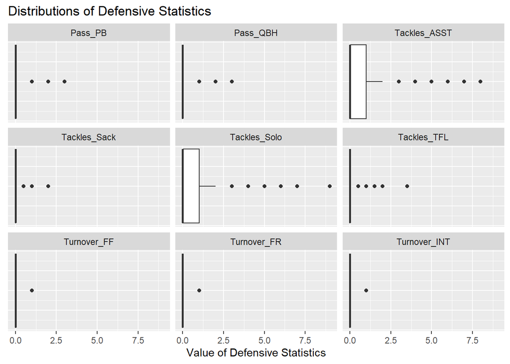

   ```r
   defClean %>%
     ggplot(aes(x=value)) + geom_boxplot() + facet_wrap(~stat) + theme(axis.text.y = element_blank(), axis.ticks.y = element_blank()) + ggtitle('Distributions of Defensive Statistics') + xlab('Value of Defensive Statistics')
   ```

   Forcing fumbles, recovering fumbles, and catching interceptions appear to be the most rare defensive skills as the majority of players have not shown such skills.

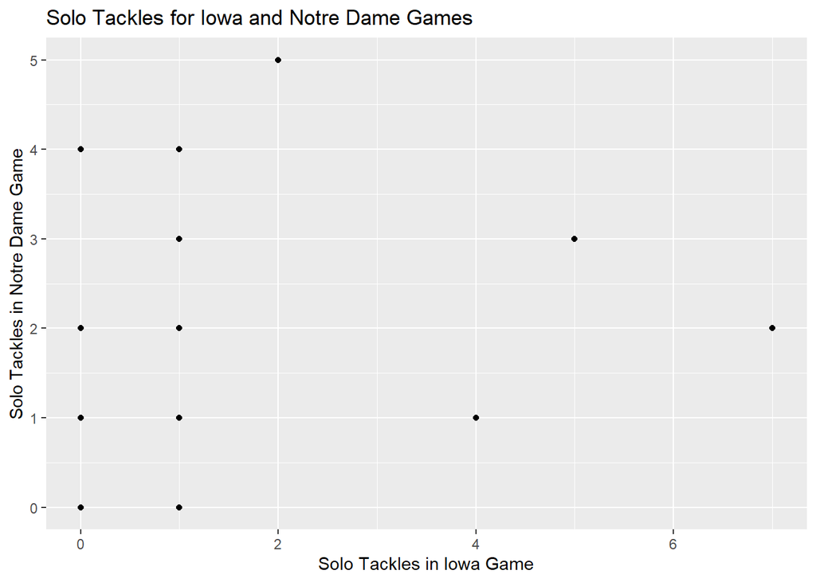

   ```r
   defClean %>%
     filter(stat == 'Tackles_Solo' & Opponent_Opponent %in% c("Iowa", "Notre Dame")) %>%
     pivot_wider(names_from=Opponent_Opponent, values_from=value) %>%
     mutate(Iowa = ifelse(is.na(Iowa), 0, Iowa), `Notre Dame` = ifelse(is.na(`Notre Dame`), 0, `Notre Dame`)) %>%
     ggplot(aes(x=Iowa, y=`Notre Dame`)) + geom_point() + ggtitle('Solo Tackles for Iowa and Notre Dame Games') + xlab('Solo Tackles in Iowa Game') + ylab('Solo Tackles in Notre Dame Game')
   ```

   Based on the scatterplot, ISU had better defense against Notre Dame because there were more solo tackles in the Notre Dame game than the Iowa game.

4. ```r
   bioClean <- bioClean %>%
     separate(Hometown, c('City', 'State'), sep=', ')
   bioClean %>%
     select(City, State) %>%
     head
   ```

   ```
   ## # A tibble: 6 x 2
   ##   City          State
   ##   <chr>         <chr>
   ## 1 Cedar Rapids  Iowa
   ## 2 Nixa          Mo.
   ## 3 Seffner       Fla.
   ## 4 Naperville    Ill.
   ## 5 Grand Prairie Texas
   ## 6 Clarksdale    Miss.
   ```

5. ```r
   bioClean %>%
     group_by(State) %>%
     summarize(count = n()) %>%
     distinct(State, count) %>%
     arrange(desc(count), State)
   ```

   ```
   ## # A tibble: 19 x 2
   ##    State     count
   ##    <chr>     <int>
   ##  1 Iowa         35
   ##  2 Fla.         10
   ##  3 Ohio          7
   ##  4 Mo.           6
   ##  5 Texas         6
   ##  6 Wis.          6
   ##  7 Ill.          5
   ##  8 Ariz.         4
   ##  9 Ga.           4
   ## 10 Mich.         4
   ## 11 Minn.         4
   ## 12 Calif.        3
   ## 13 Kan.          3
   ## 14 Okla.         2
   ## 15 S.D.          2
   ## 16 Ark.          1
   ## 17 Australia     1
   ## 18 Miss.         1
   ## 19 Pa.           1
   ```

## Part three: Joining data frames

1. ```r
   bioClean %>%
     semi_join(offClean, by='Name') %>%
     group_by(State) %>%
     summarize(count = n()) %>%
     distinct(State, count) %>%
     arrange(desc(count), State)
   ```

   ```
   ## # A tibble: 11 x 2
   ##    State count
   ##    <chr> <int>
   ##  1 Fla.      2
   ##  2 Okla.     2
   ##  3 Ariz.     1
   ##  4 Ark.      1
   ##  5 Ga.       1
   ##  6 Ill.      1
   ##  7 Iowa      1
   ##  8 Kan.      1
   ##  9 Mo.       1
   ## 10 Ohio      1
   ## 11 Texas     1
   ```

   ```r
   bioClean %>%
     semi_join(defClean, by='Name') %>%
     group_by(State) %>%
     summarize(count = n()) %>%
     distinct(State, count) %>%
     arrange(desc(count), State)
   ```

   ```
   ## # A tibble: 12 x 2
   ##    State  count
   ##    <chr>  <int>
   ##  1 Iowa       7
   ##  2 Fla.       4
   ##  3 Ga.        3
   ##  4 Ohio       3
   ##  5 Calif.     2
   ##  6 Mo.        2
   ##  7 Okla.      2
   ##  8 Texas      2
   ##  9 Wis.       2
   ## 10 Ark.       1
   ## 11 Kan.       1
   ## 12 Mich.      1
   ```

   The first table shows the states from which offensive players come. The second table shows the states from which defensive players come.

2. ```r
   all <- defClean %>%
     pivot_wider(names_from='stat', values_from='value') %>%
     full_join(offClean, by=c('Name', 'Opponent_Opponent')) %>%
     pivot_longer(c(-Name, -Opponent_Opponent), names_to='stat') %>%
     mutate(value = ifelse(is.na(value), 0, value))
   all %>%
     filter(Name != 'Purdy, Brock') %>%
     group_by(stat) %>%
     summarize(team = mean(value)) %>%
     inner_join(all %>%
                  filter(Name == 'Purdy, Brock') %>%
                  group_by(stat) %>%
                  summarize(Brock = mean(value)), by='stat') %>%
     filter(Brock >= team) %>%
     select(stat)
   ```

   ```
   ## # A tibble: 7 x 1
   ##   stat
   ##   <chr>
   ## 1 Passing_CMP-ATT
   ## 2 Passing_INT
   ## 3 Passing_TD
   ## 4 Passing_YDS
   ## 5 Rushing_ATT
   ## 6 Rushing_TD
   ## 7 Rushing_YDS
   ```

   According to the list above, Brock Purdy had better statistics than the average of the rest of the team in pass completion, passing touchdowns, passing yards, rushing attempts, rushing touchdowns, and rushing yards. This makes sense because, as quaterback, Brock Purdy had to throw the ball down the field to receivers as well as run the ball when no receivers were open. Unfortunately, this also means Brock throws more interceptions than anyone else on the team.

3. ```r
   defense2018 <- read_excel('cyclonesFootball2018.xlsx', sheet='Defensive')
   offense2018 <- read_excel('cyclonesFootball2018.xlsx', sheet='Offensive')
   defense2018
   ```

   ```
   ## # A tibble: 446 x 11
   ##    Name  Opponent_Oppone~ Tackles_Solo Tackles_ASST Tackles_TFL Tackles_Sack
   ##    <chr> <chr>            <chr>        <chr>        <chr>       <chr>
   ##  1 Eisw~ Iowa             3            3            0           0
   ##  2 Eisw~ Oklahoma         6            8            1.0         0
   ##  3 Eisw~ Akron            7            2            1.0         0
   ##  4 Eisw~ TCU              6            3            0           0
   ##  5 Eisw~ Oklahoma State   3            0            1.0         0
   ##  6 Eisw~ West Virginia    5            3            1.0         1.0
   ##  7 Eisw~ Texas Tech       3            2            0           0
   ##  8 Eisw~ Kansas           7            1            0           0
   ##  9 Eisw~ Baylor           2            4            0           0
   ## 10 Eisw~ Texas            9            3            0           0
   ## # ... with 436 more rows, and 5 more variables: Turnover_FF <chr>,
   ## #   Turnover_FR <chr>, Turnover_INT <chr>, Pass_QBH <chr>, Pass_PB <chr>
   ```

   ```r
   offense2018
   ```

   ```
   ## # A tibble: 168 x 12
   ##    Name  Opponent_Oppone~ Receiving_REC Receiving_YDS Receiving_TD Rushing_ATT
   ##    <chr> <chr>            <chr>         <chr>         <chr>        <chr>
   ##  1 Jone~ Iowa             1             31            0            <NA>
   ##  2 Jone~ Oklahoma         9             66            0            <NA>
   ##  3 Jone~ Akron            6             39            0            <NA>
   ##  4 Jone~ TCU              3             23            0            <NA>
   ##  5 Jone~ Oklahoma State   6             37            1            <NA>
   ##  6 Jone~ West Virginia    1             32            1            <NA>
   ##  7 Jone~ Texas Tech       1             4             0            <NA>
   ##  8 Jone~ Kansas           4             31            0            <NA>
   ##  9 Jone~ Baylor           4             39            1            <NA>
   ## 10 Jone~ Texas            0             0             0            <NA>
   ## # ... with 158 more rows, and 6 more variables: Rushing_YDS <chr>,
   ## #   Rushing_TD <chr>, `Passing_CMP-ATT` <chr>, Passing_YDS <chr>,
   ## #   Passing_TD <chr>, Passing_INT <chr>
   ```

   ```r
   defClean2018 <- defense2018 %>%
     mutate(
       Name = factor(Name),
       Opponent_Opponent = factor(Opponent_Opponent),
       across(c(-Name, -Opponent_Opponent), as.numeric)
     )
   offClean2018 <- offense2018 %>%
     separate(`Passing_CMP-ATT`, c('CMP', 'ATT')) %>%
     mutate(
       Name = factor(Name),
       Opponent_Opponent = factor(Opponent_Opponent),
       across(c(-Name, -Opponent_Opponent), as.numeric),
       `Passing_CMP-ATT` = as.numeric(CMP) / as.numeric(ATT)
     ) %>%
     mutate(
       Receiving_REC = ifelse(is.na(Receiving_REC), 0, Receiving_REC),
       Receiving_YDS = ifelse(is.na(Receiving_YDS), 0, Receiving_YDS),
       Receiving_TD = ifelse(is.na(Receiving_TD), 0, Receiving_TD),
       Rushing_ATT = ifelse(is.na(Rushing_ATT), 0, Rushing_ATT),
       Rushing_YDS = ifelse(is.na(Rushing_YDS), 0, Rushing_YDS),
       Rushing_TD = ifelse(is.na(Rushing_TD), 0, Rushing_TD),
       Passing_YDS = ifelse(is.na(Passing_YDS), 0, Passing_YDS),
       Passing_TD = ifelse(is.na(Passing_TD), 0, Passing_TD),
       Passing_INT = ifelse(is.na(Passing_INT), 0, Passing_INT),
       `Passing_CMP-ATT` = ifelse(is.na(`Passing_CMP-ATT`), 0, `Passing_CMP-ATT`)
     ) %>%
     select(-CMP, -ATT)
   defClean2018
   ```

   ```
   ## # A tibble: 446 x 11
   ##    Name  Opponent_Oppone~ Tackles_Solo Tackles_ASST Tackles_TFL Tackles_Sack
   ##    <fct> <fct>                   <dbl>        <dbl>       <dbl>        <dbl>
   ##  1 Eisw~ Iowa                        3            3           0            0
   ##  2 Eisw~ Oklahoma                    6            8           1            0
   ##  3 Eisw~ Akron                       7            2           1            0
   ##  4 Eisw~ TCU                         6            3           0            0
   ##  5 Eisw~ Oklahoma State              3            0           1            0
   ##  6 Eisw~ West Virginia               5            3           1            1
   ##  7 Eisw~ Texas Tech                  3            2           0            0
   ##  8 Eisw~ Kansas                      7            1           0            0
   ##  9 Eisw~ Baylor                      2            4           0            0
   ## 10 Eisw~ Texas                       9            3           0            0
   ## # ... with 436 more rows, and 5 more variables: Turnover_FF <dbl>,
   ## #   Turnover_FR <dbl>, Turnover_INT <dbl>, Pass_QBH <dbl>, Pass_PB <dbl>
   ```

   ```r
   offClean2018
   ```

   ```
   ## # A tibble: 168 x 12
   ##    Name  Opponent_Oppone~ Receiving_REC Receiving_YDS Receiving_TD Rushing_ATT
   ##    <fct> <fct>                    <dbl>         <dbl>        <dbl>       <dbl>
   ##  1 Jone~ Iowa                         1            31            0           0
   ##  2 Jone~ Oklahoma                     9            66            0           0
   ##  3 Jone~ Akron                        6            39            0           0
   ##  4 Jone~ TCU                          3            23            0           0
   ##  5 Jone~ Oklahoma State               6            37            1           0
   ##  6 Jone~ West Virginia                1            32            1           0
   ##  7 Jone~ Texas Tech                   1             4            0           0
   ##  8 Jone~ Kansas                       4            31            0           0
   ##  9 Jone~ Baylor                       4            39            1           0
   ## 10 Jone~ Texas                        0             0            0           0
   ## # ... with 158 more rows, and 6 more variables: Rushing_YDS <dbl>,
   ## #   Rushing_TD <dbl>, Passing_YDS <dbl>, Passing_TD <dbl>, Passing_INT <dbl>,
   ## #   `Passing_CMP-ATT` <dbl>
   ```

   ```r
   defense1819 <- defClean2018 %>%
     pivot_longer(c(-Name, -Opponent_Opponent), names_to='stat', values_to='2018') %>%
     group_by(Name, stat) %>%
     summarize(total2018 = sum(`2018`)) %>%
     inner_join(defClean %>%
                  group_by(Name, stat) %>%
                  summarize(total2019 = sum(value)), by=c('Name', 'stat'))
   offense1819 <- offClean2018 %>%
     pivot_longer(c(-Name, -Opponent_Opponent), names_to='stat', values_to='2018') %>%
     group_by(Name, stat) %>%
     summarize(total2018 = sum(`2018`)) %>%
     inner_join(offClean %>%
                  pivot_longer(c(-Name, -Opponent_Opponent), names_to='stat') %>%
                  group_by(Name, stat) %>%
                  summarize(total2019 = sum(value)), by=c('Name', 'stat'))
   defImprove <- defense1819 %>%
     mutate(diff = total2019 - total2018) %>%
     arrange(desc(diff))
   defImprove
   ```

   ```
   ## # A tibble: 252 x 5
   ## # Groups:   Name [28]
   ##    Name              stat         total2018 total2019  diff
   ##    <fct>             <chr>            <dbl>     <dbl> <dbl>
   ##  1 Johnson , Anthony Tackles_Solo        22        47    25
   ##  2 Petersen, Zach    Tackles_Solo         1        23    22
   ##  3 Vance, O'Rien     Tackles_ASST        10        32    22
   ##  4 Vance, O'Rien     Tackles_Solo        14        34    20
   ##  5 White, Lawrence   Tackles_ASST        14        34    20
   ##  6 Petersen, Zach    Tackles_ASST         3        18    15
   ##  7 White, Lawrence   Tackles_Solo        36        50    14
   ##  8 Azunna, Arnold    Tackles_ASST         0        12    12
   ##  9 Azunna, Arnold    Tackles_Solo         8        18    10
   ## 10 Akers, Landen     Tackles_Solo         1         9     8
   ## # ... with 242 more rows
   ```

   ```r
   defImprove %>%
     group_by(stat) %>%
     summarize(max = max(diff)) %>%
     inner_join(defImprove, by=c('stat', max = 'diff')) %>%
     select(Name, stat, max) %>%
     arrange(stat, Name)
   ```

   ```
   ## # A tibble: 12 x 3
   ##    Name              stat           max
   ##    <fct>             <chr>        <dbl>
   ##  1 Eisworth, Greg    Pass_PB          5
   ##  2 Johnson , Anthony Pass_PB          5
   ##  3 Vance, O'Rien     Pass_QBH         5
   ##  4 Vance, O'Rien     Tackles_ASST    22
   ##  5 McDonald, Will    Tackles_Sack     5
   ##  6 Vance, O'Rien     Tackles_Sack     5
   ##  7 Johnson , Anthony Tackles_Solo    25
   ##  8 Johnson , Anthony Tackles_TFL      6
   ##  9 Johnson , Anthony Turnover_FF      2
   ## 10 Petersen, Zach    Turnover_FF      2
   ## 11 Uwazurike, Eyioma Turnover_FR      2
   ## 12 White, Lawrence   Turnover_INT     2
   ```

   ```r
   offImprove <- offense1819 %>%
     mutate(diff = total2019 - total2018) %>%
     arrange(desc(diff))
   offImprove
   ```

   ```
   ## # A tibble: 80 x 5
   ## # Groups:   Name [8]
   ##    Name             stat          total2018 total2019  diff
   ##    <fct>            <chr>             <dbl>     <dbl> <dbl>
   ##  1 Purdy, Brock     Passing_YDS        2250      3982  1732
   ##  2 Kolar, Charlie   Receiving_YDS       137       697   560
   ##  3 Jones, Deshaunte Receiving_YDS       366       877   511
   ##  4 Milton, Tarique  Receiving_YDS       417       722   305
   ##  5 Lang, Johnnie    Rushing_YDS          79       238   159
   ##  6 Allen, Chase     Receiving_YDS        84       167    83
   ##  7 Jones, Deshaunte Passing_YDS           0        51    51
   ##  8 Kolar, Charlie   Receiving_REC        11        51    40
   ##  9 Jones, Deshaunte Receiving_REC        43        76    33
   ## 10 Lang, Johnnie    Rushing_ATT          22        50    28
   ## # ... with 70 more rows
   ```

   ```r
   offImprove %>%
     group_by(stat) %>%
     summarize(max = max(diff)) %>%
     inner_join(offImprove, by=c('stat', max = 'diff')) %>%
     select(Name, stat, max) %>%
     arrange(stat, Name)
   ```

   ```
   ## # A tibble: 10 x 3
   ##    Name           stat                max
   ##    <fct>          <chr>             <dbl>
   ##  1 Purdy, Brock   Passing_CMP-ATT    2.62
   ##  2 Purdy, Brock   Passing_INT        2
   ##  3 Purdy, Brock   Passing_TD        11
   ##  4 Purdy, Brock   Passing_YDS     1732
   ##  5 Kolar, Charlie Receiving_REC     40
   ##  6 Kolar, Charlie Receiving_TD       4
   ##  7 Kolar, Charlie Receiving_YDS    560
   ##  8 Lang, Johnnie  Rushing_ATT       28
   ##  9 Purdy, Brock   Rushing_TD         3
   ## 10 Lang, Johnnie  Rushing_YDS      159
   ```

   ```r
   defense1819 %>%
     filter(total2019 > total2018) %>%
     group_by(Name) %>%
     summarize(count = n()) %>%
     full_join(offense1819 %>%
                 filter(total2019 > total2018) %>%
                 group_by(Name) %>%
                 summarize(count = n()), by='Name') %>%
     mutate(
       count.x = ifelse(is.na(count.x), 0, count.x),
       count.y = ifelse(is.na(count.y), 0, count.y)
     ) %>%
     mutate(count = count.x + count.y) %>%
     select(Name, count) %>%
     arrange(desc(count), Name)
   ```

   ```
   ## # A tibble: 30 x 2
   ##    Name              count
   ##    <fct>             <dbl>
   ##  1 Jones, Deshaunte      7
   ##  2 Petersen, Zach        7
   ##  3 Azunna, Arnold        6
   ##  4 Johnson , Anthony     6
   ##  5 Lang, Johnnie         6
   ##  6 Rose, Mike            6
   ##  7 Uwazurike, Eyioma     6
   ##  8 Vance, O'Rien         6
   ##  9 White, Lawrence       6
   ## 10 McDonald, Will        5
   ## # ... with 20 more rows
   ```

   Deshaunte Jones and Zach Petersen made the most progress over the last year. Both Deshaunte and Zach improved in 7 offensive and defensive statistics. Azunna Arnold, Anothony Johnson, Johnnie Lang, Mike Rose, Eyioma Uwazurike, O’Rien Vance, and Lawrence White all improved in 6 offensive and defensive statistics.

   This was determined by pivoting the 2018 defensive statistics from multiple columns to a single column with multiple rows and then grouping the rows by name and stat and then summing to find the total for each statistic for each player for the entire season. The same procedure was performed with the 2019 defensive, 2018 offensive, and 2019 offensive statistics dataframes. Then, the 2018 and 2019 defensive summed statistics dataframes were joined using an inner join to ensure that only players who played defense in both years were kept. The 2018 and 2019 offensive summed statistics were also joined in the same manner.

   Then, both the defensive and offensive summed statistics dataframes were filtered only for statistics that improved (i.e. 2019 total was greater than 2018 total) and the rows were grouped by player and then totaled. The two resulting dataframes were joined using a full join since players may not have played both offense and defense, and the two count columns were summed (with players who only played offense or defense but not both having NA counts replaced with 0). The resulting table was sorted by count descending to show which players had the most statistics improve from 2018 to 2019.

   In addition, for individual improvements in statistics, Brock Purdy improved the most in passing yards, pass completion percentage, passing touchdowns, and rushing touchdowns but threw more interceptions. Charlie Kolar improved the most in receiving yards, receiving touchdowns, and receptions. Johnnie Lang improved the most in rushing yards and rushing attempts. Anthony Johnson improved the most in solo tackles and tackles for loss and tied with Zach Petersen for most forced fumbles and with Greg Eisworth for most passes blocked. O’Rien Vance improved the most in pressuring the quarterback and assisted tackles and tied with Will McDonald for sacks. Eyioma Uwazurike improved the most in fumbles recovered and Lawrence White improved the most in interceptions caught.

   This analysis was determined by adding a column to both the offensive and defensive total dataframes which indicated the difference between the 2018 and 2019 total and then grouping by statistic and finding the max difference and then joining back with the original dataframes using the stat and max columns (where max matches with diff).